# 【20220526回家作業】

### 我有資金100萬元，

### 一張股票是1000股，假設股價100元。

### • 某策略在這檔股票可能的損益為(12,-5,3,-4,18,-10,-2,5,2,-3) 元/股

#### •1. 用報酬率當作賺賠比

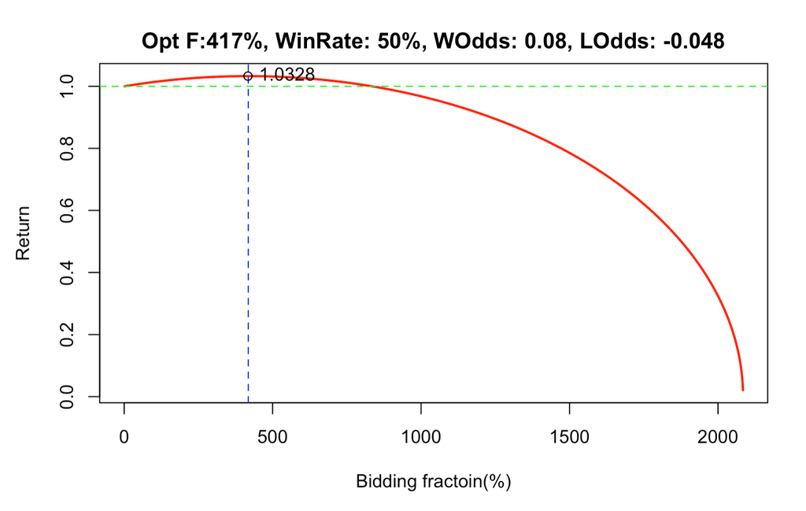

```r
odds=c(12,-5,3,-4,18,-10,-2,5,2,-3)
pwin=0.5
b1=((12+3+18+5+2)/5)/100
b2=(5+4+10+2+3)/5/100
Bid=NULL
for(f in seq(0,abs(1/b2),0.01)){
  Bid=c(Bid,((1+f*b1)^pwin)*((1-f*b2)^(1-pwin)))
}
OptF=as.numeric(which(Bid==max(Bid)))-1
plot(Bid,type='l',lwd=2,col="red",xlab="Bidding fractoin(%)",ylab="Return",
     main=paste0("Opt F:",OptF,"%",", WinRate: ",pwin*100,"%, ","WOdds: ",b1,", LOdds: -",b2))
abline(h=1,lty=2,col="green")
abline(v=order(Bid)[length(Bid)],lty=2,col="blue")
points(x=OptF,y=max(Bid),col="black")
text(x=OptF,y=max(Bid),round(max(Bid),4),pos=4,cex =1, pch = 3)
```

#### •2.Ralph Vicne’s optimal F (除上最大損失）

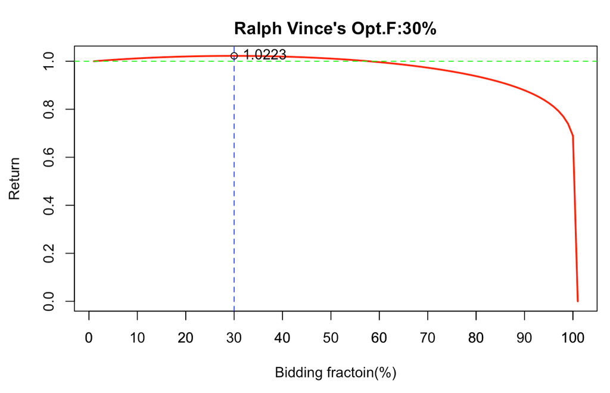

```r
odds=c(12,-5,3,-4,18,-10,-2,5,2,-3)
PL=NULL
PL=function(f){prod((1+f*((-odds)/min(odds))))^(1/length(odds))}
PL=as.numeric(lapply(seq(0,1,0.01),PL))
OptF=tail(order(PL),1)
plot(PL, type="l", col="red", lwd=2,ylab="Return",  xlab="Bidding fractoin(%)",
     main = paste0("Ralph Vince's Opt.F:",OptF,"%"))
axis(1,seq(0,100,10))
abline(h=1,col="green",lty=2)
abline(v=OptF,col="blue",lty=2)
points(x=OptF,y=max(PL),col="black")
text(x=OptF,y=max(PL),round(max(PL),4),pos=4,cex =1, pch = 3)
```

### 問1:試分別計算上述兩種最佳比例的下注方法，比較有何不同。可畫出報酬（縱軸）與下注比例（橫軸）的曲線圖

用報酬率當賺賠比的方式（一般化凱利）建議最佳下注比例是417%，而Vince則是建議最佳下注比例是30%。

從縱軸最佳比例的損益來看，兩者數值差距較小。

兩者的主要差別是，Vince是用過去發生的最大虧損當作每次輸贏最大可能損失（作為分母），每次的損益當作分子，收益=1+f*(-損益/最大虧損) ，並計算了總交易次數的幾何平均數。它避開了一般化凱利公式機率和勝賠率的限制。

### 問2:計算出來的最佳比例，該如何實際下注？

資金100萬元，一張股票1000股，假設1股100元。

公式：實際買賣張數=(剩餘資金*下注比例)/(1000股*單價)

最佳比例30%時，買入3張股票。

```r
(1000000*0.3)/(1000*100)
```

最佳比例417%時，由於股票最小單位為1股，通常買賣為1張，所以向下取整，買入41張股票。 但礙於資金只有100萬元，在無法融資的情況下，買入10張股票（全壓）。

```r
floor((1000000*4.17)/(1000*100))
```